# Informe

Alexandre Lozano

2024-11-05

## **Informe de Análisis de Datos Ómicos con `SummarizedExperiment` en R**

### Tabla de Contenidos

1. **Abstract**
2. **Objetivos del estudio**
3. **Materiales y métodos**
   - Datos
   - Herramientas y paquetes utilizados
   - Procedimiento general
4. **Resultados**
5. **Discusión, Limitaciones y Conclusiones**

### **1. Abstract**

En este análisis de datos ómicos, procesamos un conjunto de datos de metabolitos antes y después de un trasplante intestinal. Los datos provienen del `MetabolomicsWorkbench` e incluyen mediciones de intensidad para 142 metabolitos en 12 muestras. Utilizando `R` y `RStudio`, organizamos y exploramos los datos con el contenedor `SummarizedExperiment`. En este análisis, se obtuvieron distribuciones generales, un resumen estadístico de algunos de los metabolitos y un mapa de calor de correlaciones entre muestras.

### **2. Objetivos del estudio**

El objetivo principal de este análisis es explorar y describir los datos de metabolitos presentes en muestras pre y post trasplante para evaluar diferencias en los perfiles de metabolitos asociados a estas condiciones con tal de obtener una visión general de los metabolitos en las muestras y realizar un análisis descriptivo y visual para evaluar diferencias entre las condiciones y muestras.

### **3. Materiales y métodos**

#### Datos

Los datos provienen del `MetabolomicsWorkbench`, bajo el ID de estudio ST000002. Este conjunto de datos se organizó en un contenedor `SummarizedExperiment` (SE), que facilita el análisis al incluir tanto la matriz de datos de intensidades como metadatos de muestras y metabolitos. Se escogió este estudio al ser el proporcionado como `2023-UGrX-4MetaboAnalystTutorial` en los datasets del repositorio `nutrimetabolomics` de GitHub.

El repositorio de GitHub se encuentra en el siguiente link: https://github.com/alozano12/PEC1-ADO-ST000002.git

#### Herramientas utilizadas

- **Lenguaje**: `R` (versión 4.4) y `RStudio`.
- **Paquetes en R**:
  - `SummarizedExperiment`: para manejo de datos de tipo `SE`.
  - `pheatmap`: para el mapa de calor de correlación.

#### Procedimiento general

1. **Carga y exploración inicial de datos**: Organizar los datos en un objeto `SummarizedExperiment` y visualizar la estructura de datos.
2. **Exploración descriptiva**:
   - Visualizar la distribución de intensidades.
   - Calcular un resumen estadístico básico por metabolito.
   - Generar un mapa de calor de la matriz de correlación entre muestras.

### **4. Resultados**

1. **Distribución de las muestras por condición**

   Para observar la distribución de las muestras entre las condiciones pre y post trasplante, se utilizó la siguiente instrucción:

```r
library(metabolomicsWorkbenchR)
library(SummarizedExperiment)
```

```r
library(Biobase)
library(GenomeInfoDb)
library(pheatmap)

SE = do_query(
    context = 'study',
    input_item = 'study_id',
    input_value = 'ST000002',
    output_item = 'SummarizedExperiment' #
)

SE
```

```
## class: SummarizedExperiment
## dim: 142 12
## metadata(8): data_source study_id ... description subject_type
## assays(1): ''
## rownames(142): ME641269 ME641270 ... ME641409 ME641410
## rowData names(3): metabolite_name metabolite_id refmet_name
## colnames(12): LabF_684483 LabF_684487 ... LabF_684524 LabF_684528
## colData names(6): local_sample_id study_id ... raw_data Transplantation
```

El objeto `SummarizedExperiment` contiene 142 filas (metabolitos) y 12 columnas (muestras). Los metadatos incluyen 8 elementos sobre la fuente y el análisis del estudio, y los datos de filas (`rowData`) proporcionan tres columnas para cada metabolito: nombre, ID y nombre de referencia. Las muestras, identificadas en las columnas, tienen sus propios metadatos en seis categorías, como `sample_source` y `Transplantation`.

```r
colnames(SE)
```

```
##  [1] "LabF_684483" "LabF_684487" "LabF_684491" "LabF_684495" "LabF_684499"
##  [6] "LabF_684503" "LabF_684508" "LabF_684512" "LabF_684516" "LabF_684520"
## [11] "LabF_684524" "LabF_684528"
```

```r
table(colData(SE)$Transplantation)
```

```
##
##  After transplantation Before transplantation
##                      6                      6
```

En cuanto a las muetras, hay 12, como ya se ha dicho anteriormente, y sus nombres empiezan por “LabF_” seguidos por su número de referencia. Se categorizan en función de si corresponden a antes o después del transplante a través de la variable `Transplantation` , perteneciendo la mitad de ellas a cada condición, las 6 primeras, desde LabF_684483 hasta Lab_684503 son `pre-transplantation` mientras que las 6 últimas, desde Lab_684508 hasta Lab_684528 `post-transplantation`.

2. **Visualización de los distintos metabolitos**

A través de rowData, se puede ver qué información está disponible sobre cada metabolito, apareciendo tres columnas: metabolite_name (nombre del metabolito), metabolite_id (ID único del metabolito) y refmet_name (nombre de referencia del metabolito). Al contener este estudio 142 metabolitos distintos, se ha ejecutado el siguiente estudio para observar los 12 primeros y últimos metabolitos con tal de tener una visión parcial de estos.

```r
head(rownames(SE), 12)
```

```
##  [1] "ME641269" "ME641270" "ME641271" "ME641272" "ME641273" "ME641274"
##  [7] "ME641275" "ME641276" "ME641277" "ME641278" "ME641279" "ME641280"
```

```r
head(rowData(SE)$metabolite_name, 12)
```

```
##  [1] "1-monoolein"             "1-monostearin"
##  [3] "2-hydroxybutanoic acid"  "2-hydroxyglutaric acid"
##  [5] "2-ketoisocaproic acid"   "2-monopalmitin"
##  [7] "2-monostearin NIST"      "3-aminoisobutyric acid"
##  [9] "3-hydroxybutanoic acid"  "3-hydroxypropionic acid"
## [11] "3-phenyllactic acid"     "5-aminovaleric acid"
```

```r
tail(rownames(SE), 12)
```

```
##  [1] "ME641399" "ME641400" "ME641401" "ME641402" "ME641403" "ME641404"
##  [7] "ME641405" "ME641406" "ME641407" "ME641408" "ME641409" "ME641410"
```

```r
tail(rowData(SE)$metabolite_name, 12)
```

```
##  [1] "tocopherol" "trehalose"  "tryptophan" "tyramine"   "tyrosine"
##  [6] "uracil"     "urea"       "uric acid"  "uridine"    "valine"
## [11] "xanthine"   "xylose"
```

Como se puede ver, los ID de los metabolitos se encuentran empiezan por “ME” yendo de ME641269 hasta ME641410, siendo 142 en total, y cada uno corresponde a un metabolito distinto como: 1-monoolein, 2-monopalmitin, trehalose o urea, ordenados por orden alfabético según su nombre.

3. **Visualización de las mediciones de los metabolitos**

```r
head(assay(SE)[, c(1, 2, 3, 7, 8, 9)])
```

```
##    LabF_684483 LabF_684487 LabF_684491 LabF_684508 LabF_684512 LabF_684516
##          <num>       <num>       <num>       <num>       <num>       <num>
## 1:      244142        6968        1928        6047        2902        1452
## 2:       16848       10206        9398        9771        6521        1302
## 3:       11587       65635       32433       13238       29774        4134
## 4:        8276       12402       20964        7160       11501        3202
## 5:        2096        3472       10669         812        2011         738
## 6:        3405        3196        1457        1511         622         883
```

```r
tail(assay(SE)[, c(1, 2, 3, 7, 8, 9)])
```

```
##    LabF_684483 LabF_684487 LabF_684491 LabF_684508 LabF_684512 LabF_684516
##          <num>       <num>       <num>       <num>       <num>       <num>
## 1:     1384286       11141       93404          98       11990         188
## 2:      269872        1896      150207       30387         714        3899
## 3:         528         253         464         351        3894         283
## 4:      430644      918195      826226     1124633     1227642      652835
## 5:         627        1828         651        3704        8842        4668
## 6:        9049       12730        9733        3533        3267        1848
```

Como se puede observar, los valores de los metabolitos en las primeras y últimas filas muestran una amplia variabilidad, yendo desde valores muy altos, como por ejemplo 1.384.286, hasta valores bajos como 98, lo cual sugiere grandes diferencias en la abundancia de los metabolitos. Esta alta variabilidad indica que los datos pueden requerir normalización o transformación para ser comparables y facilitar análisis posteriores.

Con tal de seguir observando las mediciones de los metabolitos, se realiza la media, mediana, desviación estandar, mínimo y máximo de cada uno de estos para las 12 muestras. Se representan nuevamente los mismos metabolitos, los 6 primeros y últimos.

```r
resumen_metabolitos <- apply(assay(SE), 1, function(x) {
  c(media = mean(x, na.rm = TRUE),
    mediana = median(x, na.rm = TRUE),
    desviacion_estandar = sd(x, na.rm = TRUE),
    minimo = min(x, na.rm = TRUE),
    maximo = max(x, na.rm = TRUE))
})
resumen_metabolitos <- as.data.frame(t(resumen_metabolitos))
head(resumen_metabolitos)
```

```
##       media mediana desviacion_estandar minimo maximo
## 1 27643.333  4737.5           68585.054   1452 244142
## 2  6939.250  6155.0            4674.503   1013  16848
## 3 17779.000 12412.5           18902.527   1823  65635
## 4 16818.500 11951.5           18806.783   1109  70972
## 5  2194.917  1030.0            2823.231    432  10669
## 6  2945.417  1436.5            3922.642    622  14445
```

```r
tail(resumen_metabolitos)
```

```
##          media   mediana desviacion_estandar minimo  maximo
## 137 228805.417   11565.5          428065.849     98 1384286
## 138 126146.333   48573.0          167977.229    580  523718
## 139   1175.917     407.5            1515.528    190    4108
## 140 937512.583 1032884.5          352818.908 222010 1394436
## 141   3559.417    3112.5            3141.503    282   10089
## 142   6045.333    4928.0            4532.096    758   12902
```

Como se puede ver aquí nuevamente, hay una gran variabilidad al haber mucha diferencia entre los valores mínimos y máximos. Esto también se puede ver en la desviación estándar con valores como 428065,849 o 352818,908. Por otro lado, hay metabolitos con una desviación estándar menor, como 1515,528 en ME641407, aunque esto se debe a que las intensidades de estos metabolitos son inferiores, pudiéndose observar en el valor máximo, 4108.

4. **Correlación entre las muestras**

Con tal de ver si las muestras se encuentras correlacionadas con otras a través de sus muestras, se realiza una prueba con la función cor() y se representa con un heatmap.

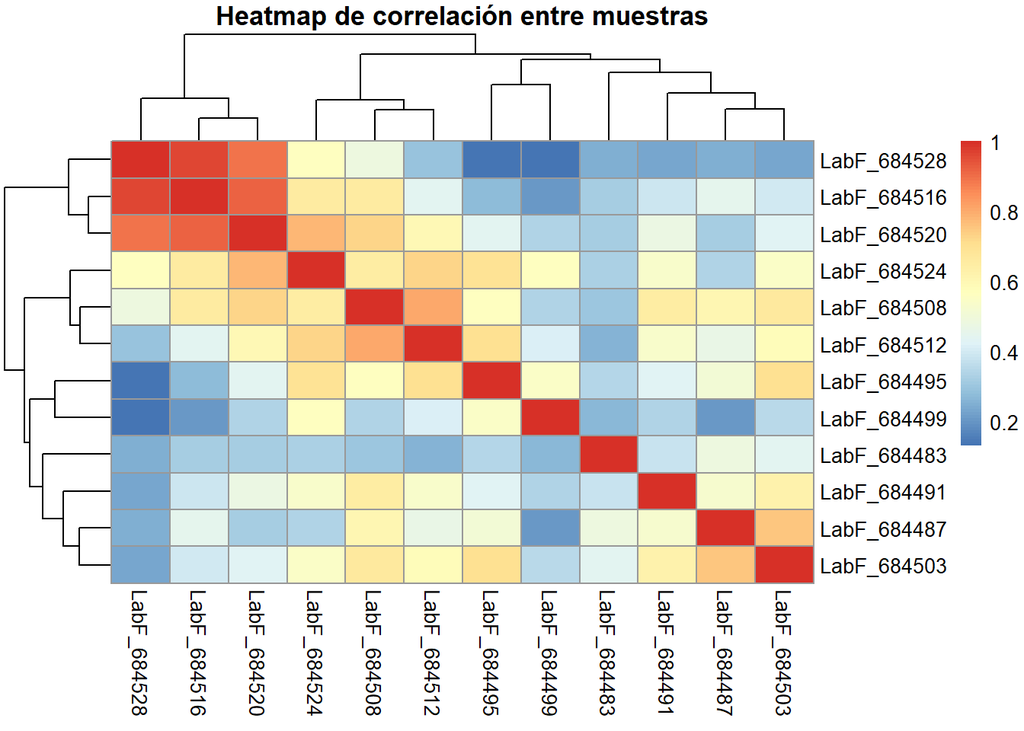

```r
correlacion <- cor(assay(SE))
pheatmap(correlacion, main = "Heatmap de correlación entre muestras")
```

Como se puede observar, si quisieramos divir en dos las muestras, 6 y 6, estas se encontrarían separadas de la misma forma que lo están en función de si corresponden a anteriores o posteriores al transplante. Además, tal y como se muestra en la parte superior izqueirda del heatmap, LabF_684528, LabF_684516 y LabF_684520 se ecuentran muy correlacionadas. Otras muestras correlacionadas entre sí son por ejemplo LabF_684487 y LabF_684503.

5. **Obsrvación de metadata**

```r
metadata(SE)
```

```
## $data_source
## [1] "Metabolomics Workbench"
##
## $study_id
## [1] "ST000002"
##
## $analysis_id
## [1] "AN000002"
##
## $analysis_summary
## [1] "GCMS positive ion mode"
##
## $units
## [1] "Peak height"
##
## $name
## [1] "ST000002:AN000002"
##
## $description
## [1] "Intestinal Samples II pre/post transplantation"
##
## $subject_type
## [1] NA
```

En el análisis de la metadata, nos informaque los datos provienen de Metabolomics Workbench, que el identificador del estudio es ST000002 y el de su análisis es AN000002, obtuviendo los datos a través del modo de ionización positiva en GCMS (cromatografía de gases y espectrometría de masas) y con altura de picos como unidades. Además, la metadata describe el contexto de los datos: `Intestinal Samples II pre/post transplantation`, señalando que el estudio comparó muestras intestinales antes y después de una intervención de trasplante.

### **5. Discusión, Limitaciones y Conclusiones**

En este análisis del dataset, exploramos los datos metabolómicos de muestras intestinales tomadas antes y después de un trasplante. Los resultados mostraron una gran variabilidad en las intensidades de los metabolitos, con valores que van desde concentraciones muy bajas hasta picos muy altos. Esto indica diferencias significativas en la abundancia de los metabolitos que pueden deberse a factores biológicos o a efectos técnicos en la medición. Esta variabilidad sugiere que sería útil aplicar ajustes o normalizaciones a los datos antes de llevar a cabo análisis más detallados, como comparaciones entre grupos.

Seguidamente, en cuanto a las limitaciones, una de las principales en este análisis es la alta variabilidad observada en las intensidades de los metabolitos, que puede deberse a factores biológicos, como las diferencias individuales en las muestras, o a factores técnicos, como variaciones en las condiciones de medición o el procesamiento de los datos. Esta variabilidad podría influir en la interpretación de los resultados, ya que valores extremos o picos podrían desviar las conclusiones si no se controlan. Para abordar este problema, sería útil aplicar técnicas de normalización y transformación a los datos, como la escala logarítmica o la normalización por media, que pueden reducir estas diferencias y hacer que las comparaciones entre muestras sean más precisas y fiables.

En conclusión, esta exploración inicial proporciona una base para continuar con el análisis de los datos metabolómicos, y resalta la importancia de realizar preprocesamientos adicionales para garantizar resultados sólidos. Además, una mayor clarificación del contexto biológico y técnico podría mejorar la interpretación y relevancia de los hallazgos en estudios posteriores.